# Bivariate analysis using Pearson correlation and scatter plot of a combination of 2 columns on Melbourne dataset

For the remaining excersices where numerical columns are needed, I will use the Melbourne Housing Market dataset  
https://www.kaggle.com/anthonypino/melbourne-housing-market?select=MELBOURNE_HOUSE_PRICES_LESS.csv

Some Key Details

Suburb: Suburb

Address: Address

Rooms: Number of rooms

Price: Price in Australian dollars

Method:  
S - property sold;  
SP - property sold prior;  
PI - property passed in;  
PN - sold prior not disclosed;  
SN - sold not disclosed;  
NB - no bid;  
VB - vendor bid;  
W - withdrawn prior to auction;  
SA - sold after auction;  
SS - sold after auction price not disclosed.  
N/A - price or highest bid not available.

Type:  
br - bedroom(s);  
h - house,cottage,villa, semi,terrace;  
u - unit, duplex;  
t - townhouse;  
dev site - development site;  
o res - other residential.

SellerG: Real Estate Agent

Distance: Distance from CBD (Central Business District) in Kilometres

Date: Date sold

Regionname: General Region (West, North West, North, North east …etc)

Propertycount: Number of properties that exist in the suburb.

Bedroom2 : Scraped # of Bedrooms (from different source)

Bathroom: Number of Bathrooms

Car: Number of carspots

Landsize: Land Size in Metres

BuildingArea: Building Size in Metres

YearBuilt: Year the house was built

CouncilArea: Governing council for the area

Lattitude: Self explanitory

Longtitude: Self explanitory

```python
import pandas as pd
import seaborn as sns
sns.set_style("dark")
```

```python
df = pd.read_csv('melbourne_housing_prices.csv', sep=',')
df.head()
```

|  | Suburb | Address | Rooms | Type | Price | Method | SellerG | Date | Postcode | Regionname | Propertycount | Distance | CouncilArea |
| --- | --- | --- | --- | --- | --- | --- | --- | --- | --- | --- | --- | --- | --- |
| 0 | Abbotsford | 49 Lithgow St | 3 | h | 1490000.0 | S | Jellis | 1/04/2017 | 3067 | Northern Metropolitan | 4019 | 3.0 | Yarra City Council |
| 1 | Abbotsford | 59A Turner St | 3 | h | 1220000.0 | S | Marshall | 1/04/2017 | 3067 | Northern Metropolitan | 4019 | 3.0 | Yarra City Council |
| 2 | Abbotsford | 119B Yarra St | 3 | h | 1420000.0 | S | Nelson | 1/04/2017 | 3067 | Northern Metropolitan | 4019 | 3.0 | Yarra City Council |
| 3 | Aberfeldie | 68 Vida St | 3 | h | 1515000.0 | S | Barry | 1/04/2017 | 3040 | Western Metropolitan | 1543 | 7.5 | Moonee Valley City Council |
| 4 | Airport West | 92 Clydesdale Rd | 2 | h | 670000.0 | S | Nelson | 1/04/2017 | 3042 | Western Metropolitan | 3464 | 10.4 | Moonee Valley City Council |

```python
houseCorrelations = df.corr(method='pearson')
houseCorrelations.style.background_gradient(cmap='coolwarm', axis=None).set_precision(2)
```

|  | Rooms | Price | Postcode | Propertycount | Distance |
| --- | --- | --- | --- | --- | --- |
| Rooms | 1.00 | 0.41 | 0.09 | -0.05 | 0.27 |
| Price | 0.41 | 1.00 | 0.00 | -0.06 | -0.25 |
| Postcode | 0.09 | 0.00 | 1.00 | -0.00 | 0.50 |
| Propertycount | -0.05 | -0.06 | -0.00 | 1.00 | 0.01 |
| Distance | 0.27 | -0.25 | 0.50 | 0.01 | 1.00 |

I expected distance to the business district and price to correlate negatively, I did expect a stronger correlation

```python
correlation = df[['Price','Distance']].corr()
correlation.style.background_gradient(cmap='coolwarm', axis=None).set_precision(2)
```

|  | Price | Distance |
| --- | --- | --- |
| Price | 1.00 | -0.25 |
| Distance | -0.25 | 1.00 |

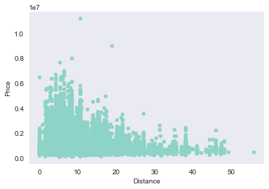

```python
df.plot(kind='scatter', x='Distance',y='Price')
```